# PCAs of mC in 100 kbp bins

Tomato TET3 BS-seq selected plants

Javier Antúnez Sánchez

March 2023

Analysis of DNA methylation in 100 kbp bins created with `CX_report2mC_bins.v1.0.pl` from Bismark CX_reports.

# Load data

When loading data we filter chromosome 9 as there is an anomaly in the mapping (and extranuclear genomes). We also remove those bins with low coverage (< 1000 reads / 100 kbp)

# PCAs

### CG PCA table

#### show table

| sample | PC1 [80%] | PC2 [16%] | PC3 [2%] | PC4 [1%] | PC5 [1%] | PC6 [0%] | condition | replica | description |
| --- | --- | --- | --- | --- | --- | --- | --- | --- | --- |
| WT_1 | -180.03796 | -60.06664 | 67.28944 | -19.5813456 | -3.815256 | 3.297709e-13 | WT | 1 | WT |
| WT_2 | -19.41963 | -157.80977 | -20.72941 | 37.1541314 | 4.781233 | 2.415672e-13 | WT | 2 | WT |
| A4_1 | -365.96887 | 119.68901 | -26.82464 | 8.6475981 | 2.485281 | 1.260381e-13 | A4 | 1 | A.T1 TET3 |
| A4_2 | 92.38667 | -46.51273 | -45.53283 | -45.5702071 | -7.722052 | 3.280397e-13 | A4 | 2 | A.T1 TET3 |
| A17_1 | 236.23779 | 78.96318 | 12.66123 | 19.6944794 | -31.152326 | 2.753492e-13 | A17 | 1 | A.T1 NT |
| A17_2 | 236.80200 | 65.73694 | 13.13620 | -0.3446562 | 35.423120 | 2.106648e-13 | A17 | 2 | A.T1 NT |

# Using the PCAs to remove ouliers

We can identify outlier samples by looking at the PCAs, those samples that constitute one Principal Component on their own will probably be outliers.

## All samples

Most of the dispersion is due to A4_1, which we already saw in the scatter plots that is a strange one

### mC

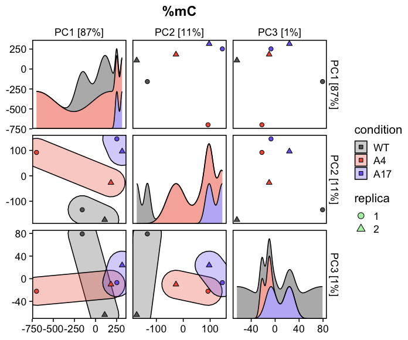

### mCG

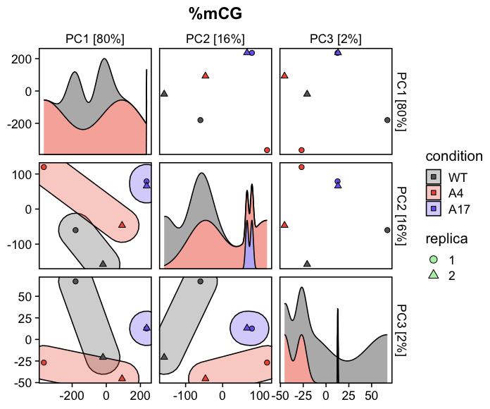

### mCHG

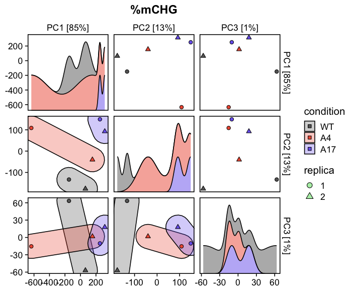

### mCHH

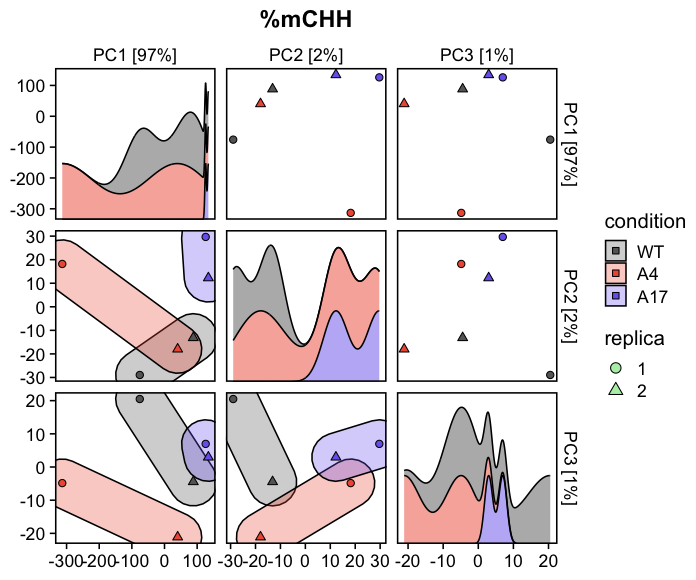

## Removing A4_1

After removing sample A4_1

### mC

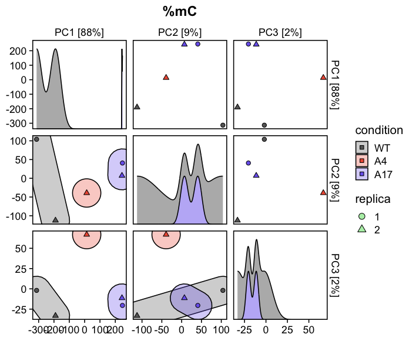

### mCG

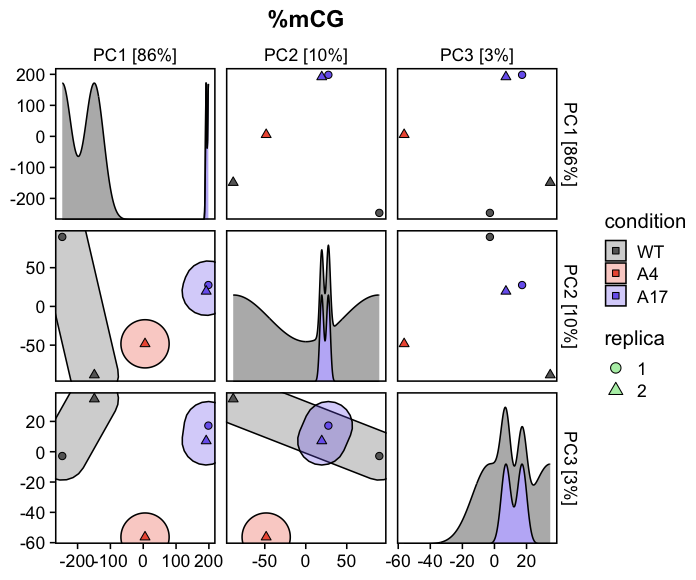

### mCHG

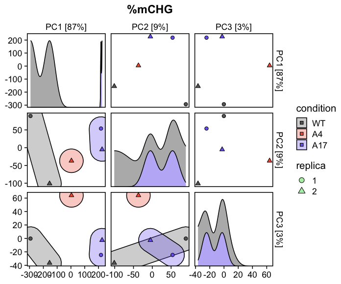

### mCHH

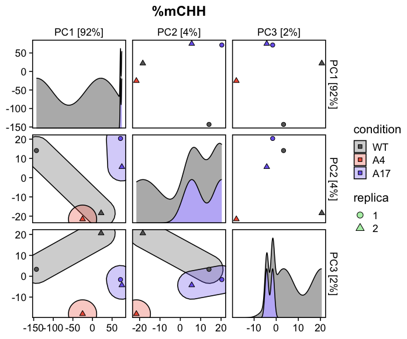

# Correlation between PC1 and %mC

## CG

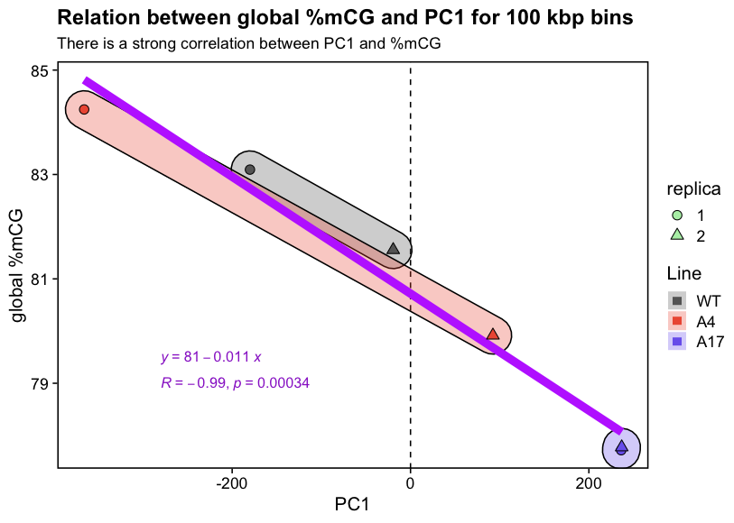

## CHG

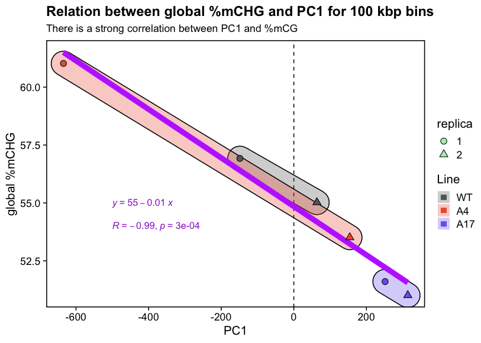

## CHH

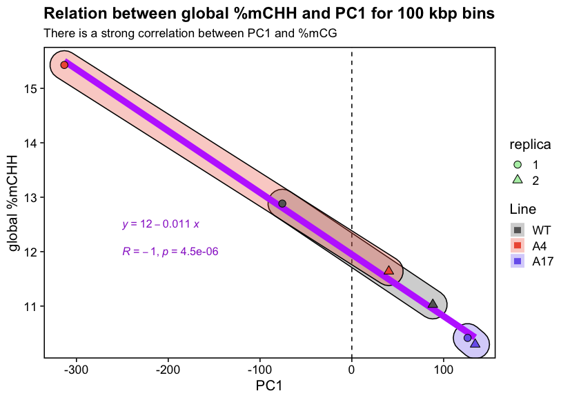